## Data Science for Business 2021/22

### Mirko Trapani

# The impact of Covid-19 on the jobs market

### Objective

- identify which categories were the most affected by the pandemic, based on age, gender, studies and so on.

### How

- *a posteriori* what-if analysis using time series prediction
- we compare a prediction of years 2020-2021 against the actual data
- the prediction is based on previous years, until 2019

## Oh no, the data doesn't add up!

### +6M jobs in 10 years?

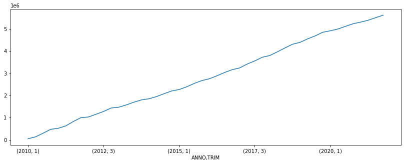

```python
(jobs-ceased).cumsum()
```

## But, why?

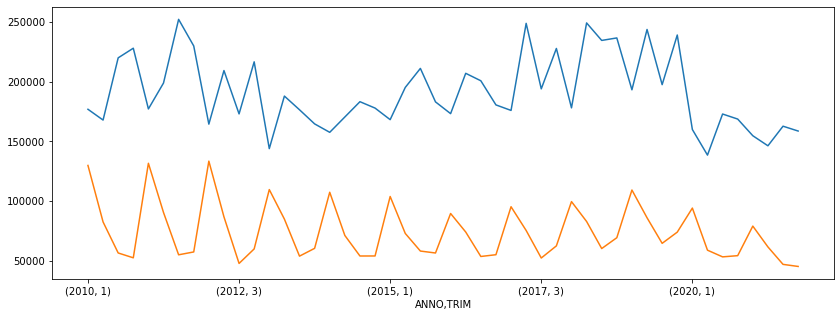

```python
jobs.plot()
ceased.plot()
```

## According to official data, job contracts have increased by ~450k in 2015-2020

[figure not shown]

## Someone (or something) ate our data, what now?

# Another source of data!

[figure not shown]

https://quadrantelavoro.regione.lombardia.it

#### CVS exports available!

## A comparison

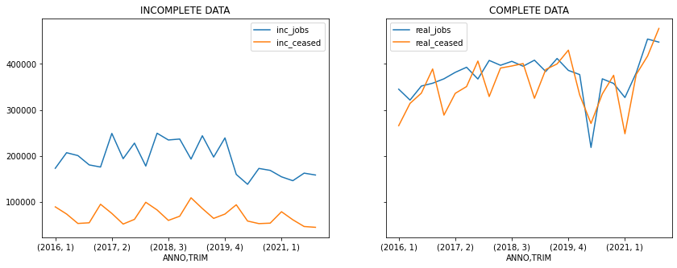

### This data is correct! but...

- it starts from 2016
- it's grouped by trimester

#### So, is it really usable for predictions? We have only 16 training data points :(

# IDEA:

If the *incomplete* and the *complete* series are strongly correlated, then we can just scale the incomplete data!

## Correlation on "Avviamenti" (we're interested in 0-lag)

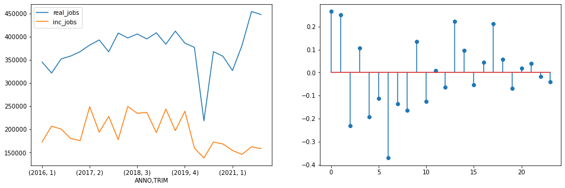

This doesn't look good!

## Correlation on "Cessazioni"

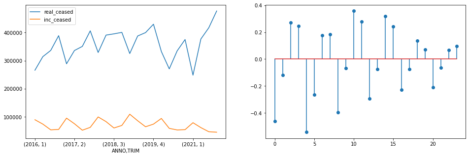

Doesn't look good either :(

## "Tempo Indeterminato" contracts probably follow different logics

### And probably *New* and *Ceased* contracts are less affected by the day of the month

Let's try that...

### "Cessazioni" still look awful

Probably "Tempo Indeterminato" contracts also tend to be terminated near the end of the month

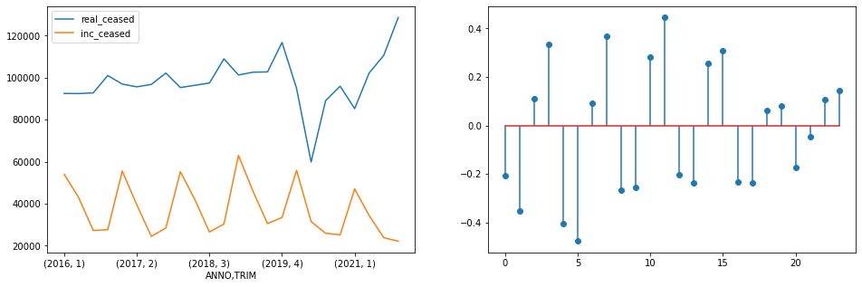

### "Avviamenti" have improved a lot

A 0.6 correlation is not very strong, but we can work with that...

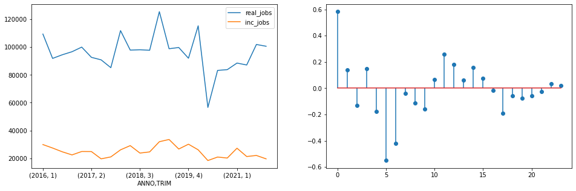

#### ... or at least let's pretend we can ;)

### Let's load the (incomplete) dataset, filtering only Tempo Indeterminato contracts, then let's...

- join it with the Ateco codes, grouping activities by macro-sectors
- generalize age, studies and citizenship into wider categories

|  | GENERE | ETA | TITOLOSTUDIO | PROVINCIAIMPRESA | ITALIANO | MESE | ANNO | GRUPPOSETTORE |
| --- | --- | --- | --- | --- | --- | --- | --- | --- |
| 399170 | F | 41-55 | TERZIARIA | MILANO | SI | 1 | 2010 | SANITA' E ASSISTENZA SOCIALE |
| 399233 | M | 41-55 | SECONDARIA SUPERIORE | CREMONA | SI | 1 | 2010 | AGRICOLTURA, SILVICOLTURA E PESCA |
| 399291 | M | 25-40 | SECONDARIA INFERIORE | BERGAMO | SI | 1 | 2010 | TRASPORTO E MAGAZZINAGGIO |
| 399292 | M | 56+ | SECONDARIA SUPERIORE | PAVIA | SI | 1 | 2010 | AGRICOLTURA, SILVICOLTURA E PESCA |
| 399294 | F | 25-40 | SECONDARIA SUPERIORE | MILANO | SI | 1 | 2010 | ATTIVITÀ DI FAMIGLIE E CONVIVENZE COME DATORI ... |
| ... | ... | ... | ... | ... | ... | ... | ... | ... |
| 9579723 | F | 41-55 | SECONDARIA SUPERIORE | MANTOVA | SI | 12 | 2021 | ALTRE ATTIVITÀ DI SERVIZI |
| 9579724 | F | 25-40 | SECONDARIA SUPERIORE | BRESCIA | NO | 12 | 2021 | COMMERCIO ALL'INGROSSO E AL DETTAGLIO - RIPARA... |
| 9579731 | M | 15-24 | SECONDARIA SUPERIORE | MILANO | SI | 12 | 2021 | SERVIZI DI INFORMAZIONE E COMUNICAZIONE |
| 9579739 | F | 41-55 | SECONDARIA SUPERIORE | BRESCIA | SI | 12 | 2021 | SANITA' E ASSISTENZA SOCIALE |
| 9579779 | M | 25-40 | SECONDARIA SUPERIORE | PAVIA | SI | 12 | 2021 | ISTRUZIONE |

809283 rows × 8 columns

### Here's how it looks like, grouped by year and month

* The peak at the start of 2015 is probably due to a change in laws regarding *Tempo Indeterminato* jobs at the beginnning of that year.

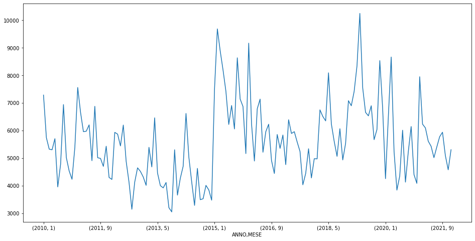

### Seasonality

While not well defined, the autocorrelation graphs seem to suggest that there's some 12-month seasonality going on, but not really strong.

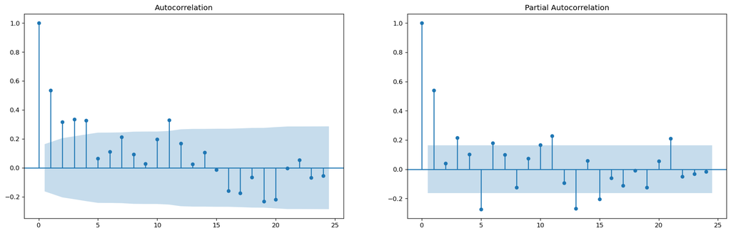

### Seasonal decomposition

Additive and multiplicative decompositions seem to confirm the impression that the time series has a seasonality but not really strong. Neither the additive nor the multiplicative models seem to fit perfectly.

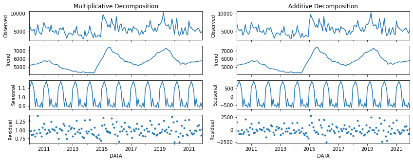

### Stationarity

The first derivative of the series appears to be stationary.

```
Series:
	ADF Statistic: -2.573104
	p-value: 0.098685

First derivative:
	ADF Statistic: -3.800374
	p-value: 0.002903
```

# Let's do some prediction with SARIMA

We will use pre-COVID data for finding the best parameters.

```
(2, 1, 3)(1, 0, 1, 12) with intercept
```

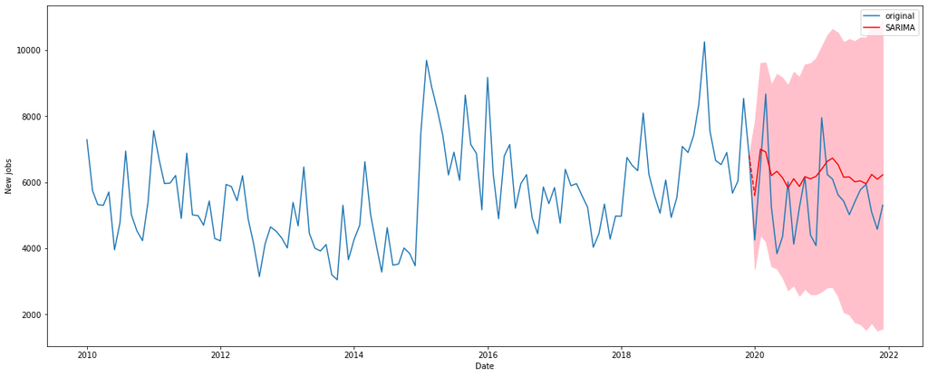

```
Difference in jobs (compared to forecasted mean): -18321.11
```

## We can automate this analysis on all the possible values of one or more attributes of the dataset, to see how they compare (*):

* standardized series

Here's for example PROVINCIAIMPRESA

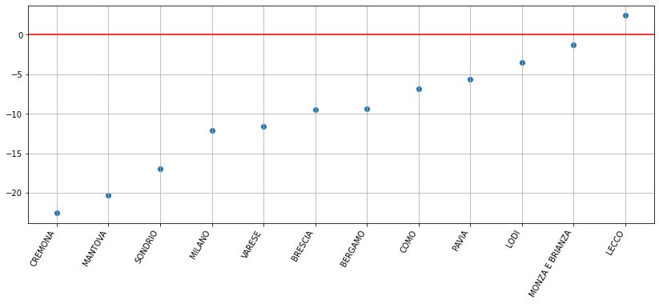

Or GRUPPOSETTORE

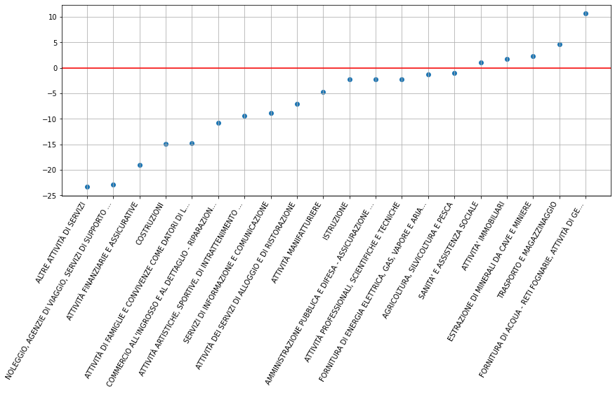

Or something more complicated like ITALIANO + GENERE + ETA

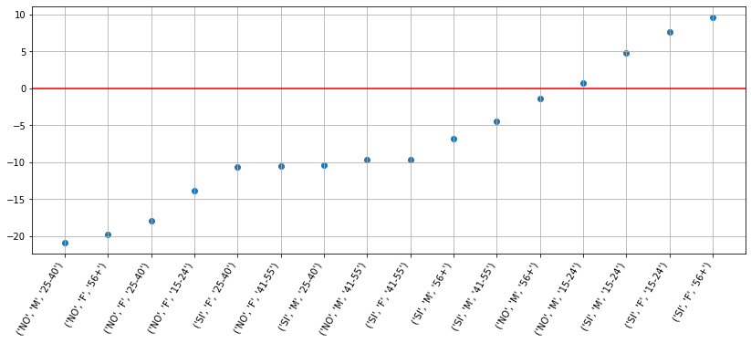

## Let's also setup a LSTM

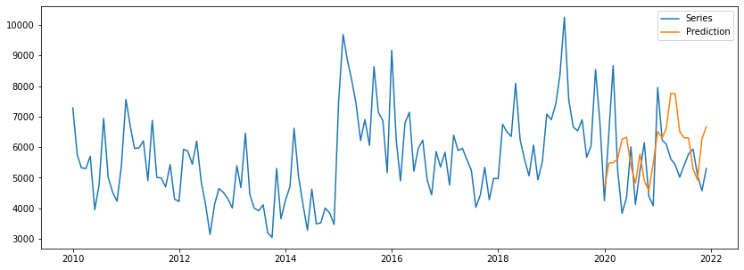

```python
_ = LSTM_predict(permanent_jobs.groupby(["ANNO", "MESE"]).size())
```

# We can play with these concepts in the dashboard...